# Assignment 1: Data set selection and initial Processing

Samantha Pang

February 14, 2023

## Install and Load Packages

```r
if (!requireNamespace("BiocManager", quietly = TRUE)){
  install.packages("BiocManager")
}
if (!requireNamespace("GEOmetadb", quietly = TRUE)){
  BiocManager::install("GEOmetadb")}


if (!requireNamespace("knitr", quietly = TRUE)){
  install.packages("knitr")}

if (!requireNamespace("edgeR", quietly = TRUE)){
  install.packages("edgeR")}

if (!requireNamespace("biomaRt", quietly = TRUE))
  BiocManager::install("biomaRt")

library("GEOmetadb")
library("knitr")
library("edgeR")
library("biomaRt")
```

## Task 1: Selecting a Dataset

Selected GSE158752’s expression data to analyze.

```r
# contact information
gse <- getGEO("GSE158752",GSEMatrix=FALSE)
kable(data.frame(head(Meta(gse))), format = "html")
```

| contact_address | contact_city | contact_country | contact_department | contact_institute | contact_laboratory |
| --- | --- | --- | --- | --- | --- |
| 3459 Fifth Ave, MUH 628 NW | Pittsburgh | USA | Medicine/Pulmonary | University of Pittsburgh | Ray |

### Information about Platform - GSE158752

**Platform title** : Illumina NextSeq 500 (Homo sapiens)  
**Submission data** : Apr 15 2014  
**Last update data** : Mar 26 2019  
**Organism** : Homo sapiens  
**Number of GEO datasets that use this techology** : 9932  
**Number of GEO samples that use this technology** : 291715

```r
# platform information (summarized above)
current_gpl <- names(GPLList(gse))[1]
current_gpl_info <- Meta(getGEO(current_gpl))
current_gpl_info$title
current_gpl_info$submission_date
current_gpl_info$last_update_date
current_gpl_info$organism
length(current_gpl_info$series_id)
length(current_gpl_info$sample_id)
```

### Get Expression Data

```r
# download folder named GSE158752 with raw counts data
sfiles = getGEOSuppFiles('GSE158752')
fnames = rownames(sfiles)
fnames
```

```
## [1] "/home/rstudio/projects/GSE158752/GSE158752_IMSA_BEC-RAW_Counts.txt.gz"
## [2] "/home/rstudio/projects/GSE158752/GSE158752_IMSA_BEC_normDESeq2_Combat.txt.gz"
```

```r
# there are 2 supplemental files, first use the one containing raw counts
ace2_exp = read.delim(fnames[1],header=TRUE,
                check.names = FALSE)

# see what the file looks like
kable(ace2_exp[1:15,1:5], format = "html")
```

| Sample | IMSA001_EPI_H | IMSA002_EPI_H | IMSA004_EPI_S | IMSA005_EPI_M |
| --- | --- | --- | --- | --- |
| A1BG | 67 | 22 | 41 | 44 |
| A1BG-AS1 | 98 | 44 | 52 | 58 |
| A1CF | 5 | 2 | 0 | 1 |
| A2M | 1226 | 594 | 1011 | 2269 |
| A2M-AS1 | 82 | 34 | 61 | 58 |
| A2ML1 | 77 | 79 | 22 | 59 |
| A2MP1 | 3 | 0 | 2 | 0 |
| A3GALT2 | 2 | 3 | 1 | 3 |
| A4GALT | 984 | 711 | 806 | 1343 |
| A4GNT | 0 | 0 | 0 | 0 |
| AA06 | 0 | 0 | 0 | 0 |
| AAAS | 1018 | 486 | 476 | 816 |
| AACS | 1668 | 975 | 1102 | 1775 |
| AACSP1 | 42 | 42 | 69 | 81 |
| AADAC | 263 | 53 | 72 | 91 |

## Task 2: Assess and Clean Data

Now that we have our expression data downloaded, we can assess and filter it.

```r
# How many genes does it have
dim(ace2_exp)
```

```
## [1] 26364    68
```

```r
colnames(ace2_exp)
```

```
##  [1] "Sample"        "IMSA001_EPI_H" "IMSA002_EPI_H" "IMSA004_EPI_S"
##  [5] "IMSA005_EPI_M" "IMSA006_EPI_M" "IMSA007_EPI_S" "IMSA008_EPI_M"
##  [9] "IMSA010_EPI_M" "IMSA011_EPI_M" "IMSA012_EPI_H" "IMSA013_EPI_S"
## [13] "IMSA015_EPI_M" "IMSA017_EPI_M" "IMSA020_EPI_H" "IMSA021_EPI_H"
## [17] "IMSA022_EPI_M" "IMSA023_EPI_M" "IMSA026_EPI_S" "IMSA027_EPI_S"
## [21] "IMSA028_EPI_M" "IMSA031_EPI_S" "IMSA034_EPI_M" "IMSA035_EPI_S"
## [25] "IMSA036_EPI_M" "IMSA037_EPI_S" "IMSA038_EPI_M" "IMSA039_EPI_S"
## [29] "IMSA040_EPI_M" "IMSA041_EPI_M" "IMSA044_EPI_S" "IMSA045_EPI_S"
## [33] "IMSA046_EPI_M" "IMSA047_EPI_M" "IMSA048_EPI_S" "IMSA049_EPI_H"
## [37] "IMSA050_EPI_M" "IMSA052_EPI_H" "IMSA053_EPI_M" "IMSA054_EPI_S"
## [41] "IMSA055_EPI_S" "IMSA056_EPI_M" "IMSA057_EPI_M" "IMSA058_EPI_M"
## [45] "IMSA059_EPI_S" "IMSA061_EPI_M" "IMSA062_EPI_S" "IMSA064_EPI_H"
## [49] "IMSA065_EPI_S" "IMSA066_EPI_M" "IMSA067_EPI_M" "IMSA068_EPI_S"
## [53] "IMSA069_EPI_H" "IMSA070_EPI_S" "IMSA071_EPI_S" "IMSA075_EPI_H"
## [57] "IMSA077_EPI_S" "IMSA078_EPI_S" "IMSA080_EPI_S" "IMSA083_EPI_H"
## [61] "IMSA085_EPI_H" "IMSA086_EPI_H" "IMSA087_EPI_S" "IMSA090_EPI_H"
## [65] "IMSA091_EPI_H" "IMSA093_EPI_H" "IMSA094_EPI_S" "IMSA098_EPI_H"
```

The initial coverage is 26364 genes. There are 67 samples in total: 3 different diagnosis representing by the last initial.  
H: Healthy Control  
M: M/M Asthma (mild to moderate asthma)  
S: Severe Asthma

### Clean Data

Check for duplicate genes

```r
# Get the summarized counts for each gene
summarized_gene_counts <- sort(table(ace2_exp$Sample),
                               decreasing = TRUE)
# Check the columns to see the frequency of genes
kable(table(ace2_exp$Sample)[1:3], format="html")
```

| Var1 | Freq |
| --- | --- |
| A1BG | 1 |
| A1BG-AS1 | 1 |
| A1CF | 1 |

```r
# Check for duplicates (where frequency is greater than 1)
knitr::kable(summarized_gene_counts[which(summarized_gene_counts>1)[1:5]], format="html")
```

| Var1 | Freq |
| --- | --- |
| NA | NA |
| NA | NA |
| NA | NA |
| NA | NA |
| NA | NA |

```r
# There aren't any duplicate genes in this data as it shows all NA
```

### Group sample data

Using the column names, we can identify each sample and assign them to groups. They follow the naming scheme of IMSA[XXX]_EPI_[H or M or S], where [XXX] refers the the patient number and [H or M or S] refers to the diagnosis groups (Healthy, M/M, or Severe Asthma).

```r
# Extract the part of column names between "IMSA" and "_S"
samples <- data.frame(lapply(colnames(ace2_exp)[2:68],
                      function(x){gsub("^.*(.)$", "\\1", x)}))
colnames(samples) <- colnames(ace2_exp)[2:68]
rownames(samples) <- c("Diagnosis")
samples <- data.frame(t(samples))
table(samples['Diagnosis'])
```

```
## Diagnosis
##  H  M  S
## 17 25 25
```

### Filter out low count genes

Using edgeR to translate counts into “counts per million”.

```r
# edgeR function cpm to translate counts to "counts per million"
cpms = cpm(ace2_exp[,3:22])
rownames(cpms) <- ace2_exp[,1]

# get rid of low counts (remove features without at least 1 read per million in n of the samples)
# n = size of the smallest group of replicates (in this data, n = 17)
keep = rowSums(cpms >1) >=17
ace2_exp_filtered = ace2_exp[keep,]
dim(ace2_exp_filtered)
```

```
## [1] 14221    68
```

After filtering out low counts, there are 14221 genes.

## Task 3: Apply normalization to dataset

### Boxplot (before normalization)

Distribution of expression data.

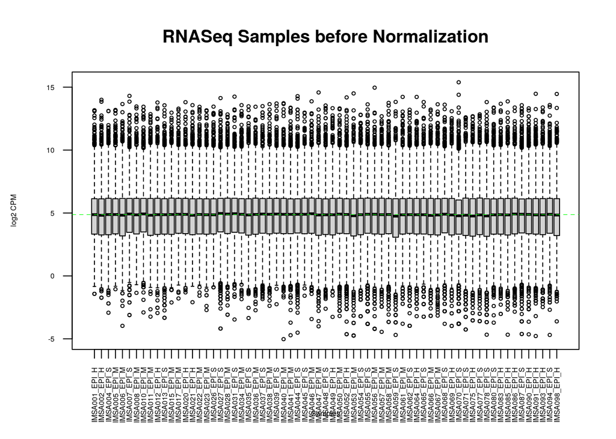

```r
data2plot <- log2(cpm(ace2_exp_filtered[, 2:68])) # log transforming the data
boxplot(data2plot, xlab = "Samples", ylab = "log2 CPM",
        las = 2, cex = 0.5, cex.lab = 0.5,
        cex.axis = 0.5, main = "RNASeq Samples before Normalization") # change title
#draw the median on each box plot
abline(h = median(apply(data2plot, 2, median)),
       col = "green", lwd = 0.6, lty = "dashed")
```

### Density Plot (before normalization)

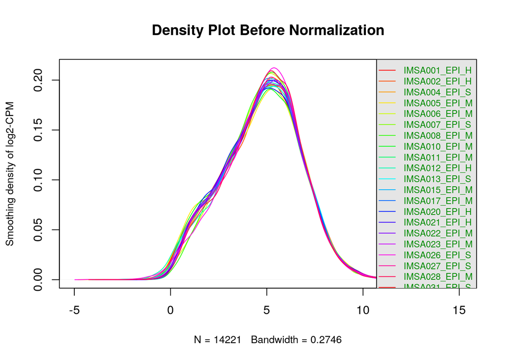

```r
counts_density <- apply(log2(cpm(ace2_exp_filtered[,3:22])), 2, density)

#calculate the limits across all the 68 samples
xlim <- 0; ylim <- 0
for (i in 1:length(counts_density)) {
  xlim <- range(c(xlim, counts_density[[i]]$x));
  ylim <- range(c(ylim, counts_density[[i]]$y))
}
cols <- rainbow(length(counts_density))
ltys <- rep(1, length(counts_density))

#plot the first density plot to initialize the plot
plot(counts_density[[1]], xlim=xlim, ylim=ylim, type="n",
     ylab="Smoothing density of log2-CPM",
     main="Density Plot Before Normalization", cex.lab = 0.85)
#plot each sample line
for (i in 1:length(counts_density))
  lines(counts_density[[i]], col=cols[i], lty=ltys[i])
#create legend
legend("topright", colnames(data2plot),
       col=cols, lty=ltys, cex=0.75,
       border ="blue",  text.col = "green4",
       merge = TRUE, bg = "gray90")
```

### Normalizing by Distribution using TMM

Trimmed Mean of M-values (TMM) normalization is a commonly used method of normalization for RNA-seq data. This method is based on the hypothesis that most genes aren’t differentially expressed. This method is facilitated using the edgeR package.

```r
# Create an edgeR container for RNASeq count data
filtered_data_matrix <- as.matrix(ace2_exp_filtered[,2:68])

rownames(filtered_data_matrix) <- ace2_exp_filtered$Sample
#Create. DGEList object
d = DGEList(counts=filtered_data_matrix, group=samples$Diagnosis)

# Calculate the normalization factors
d = calcNormFactors(d)
#get the normalized data
normalized_counts <- cpm(d)
```

### Boxplot (after normalization)

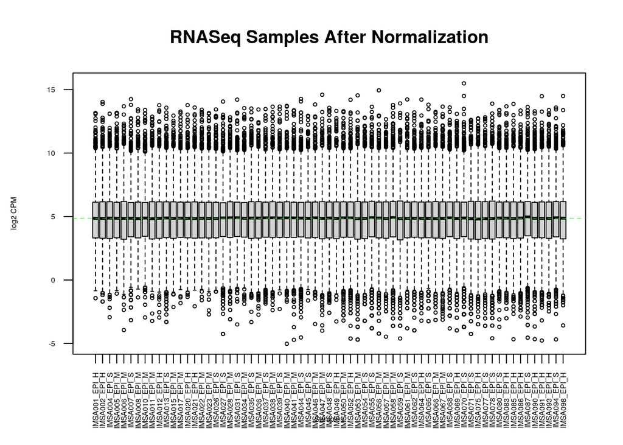

```r
data2plot <- log2(normalized_counts) # log transforming the data
boxplot(data2plot, xlab = "Samples", ylab = "log2 CPM",
        las = 2, cex = 0.5, cex.lab = 0.5,
        cex.axis = 0.5, main = "RNASeq Samples After Normalization") # change title
#draw the median on each box plot
abline(h = median(apply(data2plot, 2, median)),
       col = "green", lwd = 0.6, lty = "dashed")
```

Looking at the results before and after normalization, there is small noticable change. The medians visually align more closely.

### Distribution Plot (after normalization)

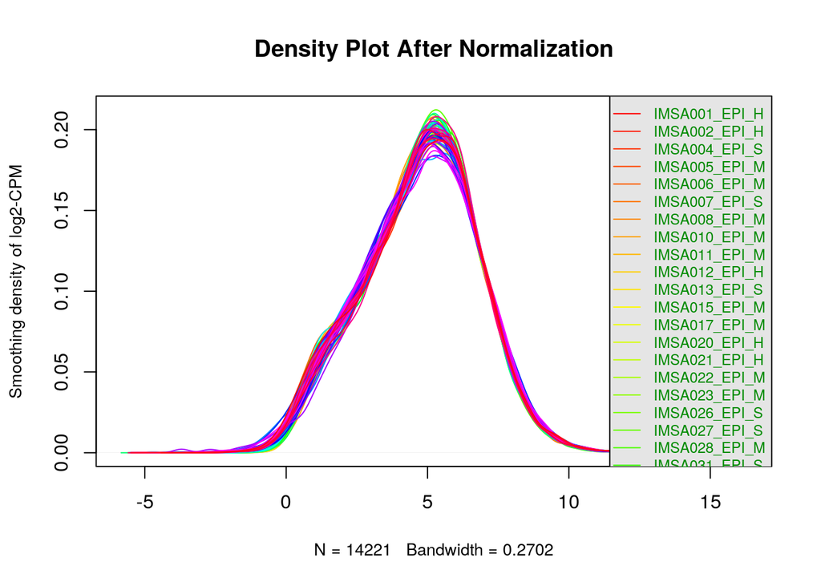

```r
counts_density <- apply(log2(normalized_counts), 2, density)

#calculate the limits across all the 68 samples
xlim <- 0; ylim <- 0
for (i in 1:length(counts_density)) {
  xlim <- range(c(xlim, counts_density[[i]]$x));
  ylim <- range(c(ylim, counts_density[[i]]$y))
}
cols <- rainbow(length(counts_density))
ltys <- rep(1, length(counts_density))

#plot the first density plot to initialize the plot
plot(counts_density[[1]], xlim=xlim, ylim=ylim, type="n",
     ylab="Smoothing density of log2-CPM",
     main="Density Plot After Normalization", cex.lab = 0.85)
#plot each sample line
for (i in 1:length(counts_density))
  lines(counts_density[[i]], col=cols[i], lty=ltys[i])
#create legend
legend("topright", colnames(data2plot),
       col=cols, lty=ltys, cex=0.75,
       border ="blue",  text.col = "green4",
       merge = TRUE, bg = "gray90")
```

Similarly to the boxplot, the sample lines seem to show very little difference. After normalization, the lines seem to show less divergence.

### MDS Plot (after normalization)

A multidimenstional scaling plot (MDS) represents the distances between samples.

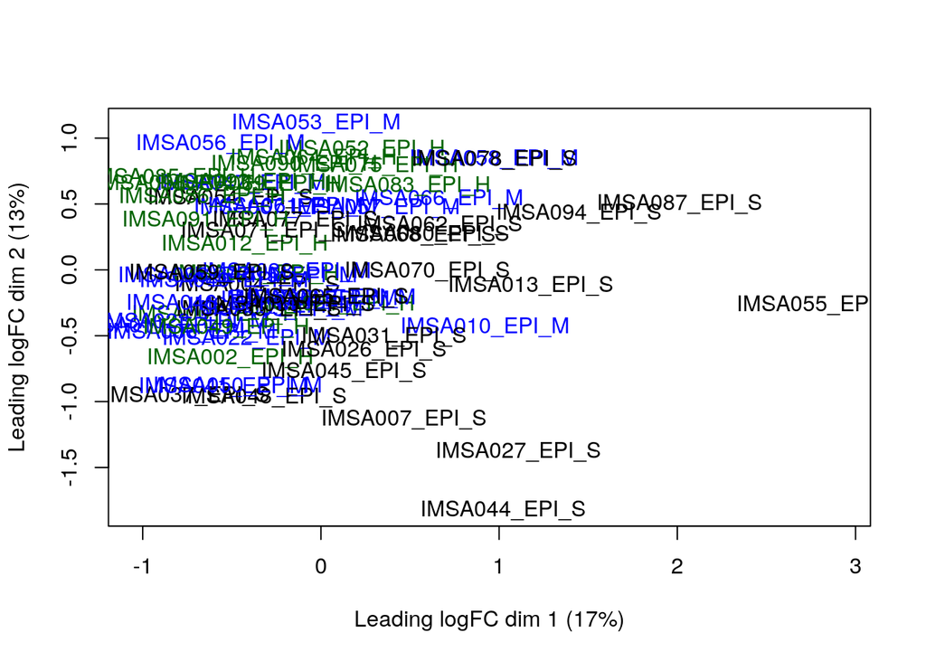

```r
plotMDS(d, labels=rownames(samples),
        col = c("darkgreen","blue")[factor(samples$Diagnosis)])
```

## Task 4: Map Identifiers

Seeing the filtered data, the genes are represented by HUGO symbols. Use biomaRt to map to HUGO symbols.

```r
# Connect to ensembl
ensembl <- useMart("ensembl")

# Use human dataset
ensembl <- useDataset("hsapiens_gene_ensembl", mart = ensembl)

# Check if HUGO symbols in dataset line up with HUGO symbols in ensembl
# convert column of gene IDs to Hugo symbols
geneMapping <- getBM(attributes = c("hgnc_symbol"),
                     mart = ensembl,
                     filters = "hgnc_symbol",
                     values = ace2_exp_filtered$Sample)
```

```
## Batch submitting query [=========>---------------------] 33% eta: 3s Batch
## submitting query [====================>----------] 67% eta: 2s
```

```r
nrow(geneMapping)
```

```
## [1] 13050
```

```r
# Difference before and after mapping
nrow(ace2_exp_filtered) - nrow(geneMapping)
```

```
## [1] 1171
```

```r
# Proportion of gene names that couldn't be mapped?
(nrow(ace2_exp_filtered) - nrow(geneMapping))/nrow(ace2_exp_filtered) * 100
```

```
## [1] 8.234301
```

```r
# 1171 gene names couldn't be mapped to HUGO symbols, meaning a proportion of  8.234301%.

# Duplicates of the HUGO symbols?
nrow(geneMapping) - length(unique(geneMapping$hgnc_symbol))
```

```
## [1] 0
```

```r
# No duplicate mapped HUGO symbols.

# merge the two data frames
normalized_counts_ids <- merge(geneMapping,normalized_counts,
by.x = 1, by.y = 0, all.y=TRUE)
knitr::kable(normalized_counts_ids[1:5,1:7],type = "html")
```

| hgnc_symbol | IMSA001_EPI_H | IMSA002_EPI_H | IMSA004_EPI_S | IMSA005_EPI_M | IMSA006_EPI_M | IMSA007_EPI_S |
| --- | --- | --- | --- | --- | --- | --- |
| A1BG-AS1 | 2.592178 | 1.939230 | 2.278447 | 1.622811 | 1.952860 | 1.676084 |
| A2M | 32.428671 | 26.179610 | 44.298262 | 63.485495 | 11.001111 | 36.538623 |
| A2M-AS1 | 2.168965 | 1.498496 | 2.672793 | 1.622811 | 1.822669 | 3.463906 |
| A4GALT | 26.027579 | 31.336200 | 35.315924 | 37.576474 | 40.814773 | 68.719429 |
| AAAS | 26.926906 | 21.419681 | 20.856551 | 22.831275 | 19.333313 | 19.777787 |

```r
# format this dataset's rownames to be HUGO symbols instead of numbers

rownames(normalized_counts_ids) <- normalized_counts_ids$hgnc_symbol
dim(normalized_counts_ids)
```

```
## [1] 14221    68
```

## Task 5: Interpretation

### What are the control and test conditions of the dataset?

The control and test conditions of the dataset were patients being categorized as healthy controls, patients with mild to moderate asthma, and patients with severe asthma. They all enrolled in ISMA (Immune Modulation in Severe Asthma) cohort where they underwent  
research bronchoscopy with endobronchial brushing.

They tested for the expression of ACE2 (angiotensin-converting enzyme-2) to see if it may be linked to patients with asthma as increased ACE2 expression suggests increased capacity for viral binding.

### Why is the dataset of interest to you?

Research into SARS-CoV-2 is relatively new and I wanted to delve into analyzing data that hasn’t depreciated over the years. I also found this dataset to be interesting as asthma is such a prevalent respiratory condition where it affects millions worldwide. Research into if individuals with asthma are more susceptible to SARS-CoV-2 is interesting as asthma and SARS-CoV-2 share many respiratory symptoms.

### Were there expression values that were not unique for specific genes? How did you handle these?

There were no duplicates in the dataset based on the gene identifiers that were analyzed from the read counts file.

### Were there expression values that could not be mapped to current HUGO symbols?

Yes, there were 1171 gene names that couldn’t be mapped to HUGO symbols. This is a proportion of 8.234301% of gene names that weren’t mapped in the merged data after mapping to HUGO symbols.

### How many outliers were removed?

The data set started out with 26,364 genes before gene were filtered out for having low counts (<1 read per million in n of the samples). Afterwards, there were 14,221. This means 12,143 outliers were removed.

### How did you handle replicates?

All replicates in the control and test data were kept in the data set. Though a majority of replicated were cut by filtering out low read counts.

### What is the final coverage of your dataset?

The final coverage of my dataset is 14,221 genes and 67 samples.

## References

*Note: All code heavily references Ruth Isserlin’s BCB420 Lectures 4 and 5 on how to assess, clean, normalize and map data.*

Camiolo, Matthew, Marc Gauthier, Naftali Kaminski, Anuradha Ray, and Sally E Wenzel. 2020. “Expression of SARS-CoV-2 Receptor ACE2 and Coincident Host Response Signature Varies by Asthma Inflammatory Phenotype.” *J. Allergy Clin. Immunol.* 146 (2): 315–324.e7.

Davis, Sean. 2022. *GEOquery: Get Data from NCBI Gene Expression Omnibus (GEO)*.

Davis, Sean, and Paul Meltzer. 2007. “GEOquery: A Bridge Between the Gene Expression Omnibus (GEO) and BioConductor.” *Bioinformatics* 14: 1846–47.

Gentleman, R., V. Carey, M. Morgan, and S. Falcon. 2022. *Biobase: Base Functions for Bioconductor*. https://bioconductor.org/packages/Biobase.

Huber, W., V. J. Carey, R. Gentleman, S. Anders, M. Carlson, B. S. Carvalho, H. C. Bravo, et al. 2015a. “Orchestrating High-Throughput Genomic Analysis with Bioconductor.” *Nature Methods* 12 (2): 115–21. http://www.nature.com/nmeth/journal/v12/n2/full/nmeth.3252.html.

Huber, W., Carey, V. J., Gentleman, R., Anders, et al. 2015b. “Orchestrating High-Throughput Genomic Analysis with Bioconductor.” *Nature Methods* 12 (2): 115–21. http://www.nature.com/nmeth/journal/v12/n2/full/nmeth.3252.html.

Isserlin, Ruth. 2023a. “BCB420. Lecture 4: Data Cleaning.”

———. 2023b. “BCB420. Lecture 4: Normalization.”

———. 2023c. “BCB420. Lecture 5: Exploratory Data Analysis and Identifier Mapping.”

Müller, Kirill, Hadley Wickham, David A. James, and Seth Falcon. 2022. *RSQLite: SQLite Interface for r*. https://CRAN.R-project.org/package=RSQLite.

R Core Team. 2022. *R: A Language and Environment for Statistical Computing*. Vienna, Austria: R Foundation for Statistical Computing. https://www.R-project.org/.

Team, The Bioconductor Dev. 2022. *BiocGenerics: S4 Generic Functions Used in Bioconductor*. https://bioconductor.org/packages/BiocGenerics.

Xie, Yihui. 2014. “Knitr: A Comprehensive Tool for Reproducible Research in R.” In *Implementing Reproducible Computational Research*, edited by Victoria Stodden, Friedrich Leisch, and Roger D. Peng. Chapman; Hall/CRC.

———. 2015. *Dynamic Documents with R and Knitr*. 2nd ed. Boca Raton, Florida: Chapman; Hall/CRC. https://yihui.org/knitr/.

———. 2023. *Knitr: A General-Purpose Package for Dynamic Report Generation in r*. https://yihui.org/knitr/.

Zhu, Jack, and Sean Davis. 2022. *GEOmetadb: A Compilation of Metadata from NCBI GEO*.

Zhu, Yuelin, Sean Davis, Robert Stephens, Paul S. Meltzer, and Yidong Chen. 2008. “GEOmetadb: Powerful Alternative Search Engine for the Gene Expression Omnibus.” *Bioinformatics (Oxford, England)* 24 (23): 2798–2800. https://doi.org/10.1093/bioinformatics/btn520.